# Checking the Imputation

## Preface

### R packages

In this practical, a number of R packages are used. If any of them are not installed you can still follow the practical but will not be able to run all of the code. The packages used (with versions that were used to generate the solutions) are:

- `mice` (version: 3.4.0)
- `RColorBrewer` (version: 1.1.2)
- `ggplot2` (version: 1.1.2)

### Help files

You can find help files for any function by adding a `?` before the name of the function.

Alternatively, you can look up the help pages online at https://www.rdocumentation.org/ or find the whole manual for a package at https://cran.r-project.org/web/packages/available_packages_by_name.html

### Dataset

For this practical, we will again use the **NHANES** dataset that we have seen in the previous practical.

To load this dataset, you can use the command `file.choose()` which opens the explorer and allows you to navigate to the location of the file `NHANES_for_practicals.RData` on your computer. If you know the path to the file, you can also use `load("<path>/NHANES_for_practicals.RData")`.

If you have not followed the first practical or if you re-loaded the NHANES data you need to re-code the variable `educ` again:

```r
NHANES$educ <- as.ordered(NHANES$educ)
```

### Imputed data

The imputed data are stored in a `mids` object called `imp` that we created in the previous practical.

You can load it into your workspace by clicking the object `imps.RData` if you are using RStudio. Alternatively, you can load this workspace using `load("<path>/imps.RData")`. You then need to run:

```r
imp <- savedimps_imp
```

The [help file](https://www.rdocumentation.org/packages/mice/versions/2.46.0/topics/mids-class) tells us that a `mids` object is a list with several elements:

| `data`: | Original (incomplete) data set. |
| --- | --- |
| `imp`: | The imputed values: A list of `ncol(data)` components, each list component is a matrix with `nmis[j]` rows and `m` columns. |
| `m`: | The number of imputations. |
| `where`: | The missingness indicator matrix. |
| `blocks` | The blocks argument of the `mice()` function. |
| `call`: | The call that created the `mids` object. |
| `nmis`: | The number of missing observations per variable. |
| `method`: | The vector imputation methods. |
| `predictorMatrix`: | The predictor matrix. |
| `visitSequence`: | The sequence in which columns are visited during imputation. |
| `formulas` | A named list of formulas corresponding the the imputed variables (blocks). |
| `post`: | A vector of strings of length `length(blocks)` with commands for post-processing. |
| `seed`: | The seed value of the solution. |
| `iteration`: | The number of iterations. |
| `lastSeedValue`: | The most recent seed value. |
| `chainMean:` | The mean of imputed values per variable and iteration: a list of `m` components. Each component is a matrix with `maxit`columns and `length(visitSequence)` rows. |
| `chainVar`: | The variances of imputed values per variable and iteration(same structure as `chainMean`). |
| `loggedEvents`: | A `data.frame` with the record of automatic corrective actions and warnings; (`NULL` if no action was made). |
| `version` | Version number of the **mice** package that created the object. |
| `date` | Date at which the object was created. |

**Details of the `loggedEvents`:**

`mice()` does some pre-processing of the data:

- variables containing missing values, that are not imputed but used as predictor are removed
  - constant variables are removed
  - collinear variables are removed

Furthermore, during each iteration

- variables (or dummy variables) that are linearly dependent are removed
  - `polr` imputation that does not converge is replaced by `polyreg`.

The `data.frame` in `loggedEvents` has the following columns:

| `it` | iteration number |
| --- | --- |
| `im` | imputation number |
| `dep` | name of the name of the variable being imputed |
| `meth` | imputation method used |
| `out` | character vector with names of altered/removed predictors |

## Evaluate the imputation

### Checking the settings

It is good practice to make sure that `mice()` has not done any processing of the data that was not planned or that you are not aware of. This means checking that the correct `method`, `predictorMatrix` and `visitSequence` were used.

#### Task

Do these checks for `imp`.

#### Solution

```r
imp$method
```

```
##           occup             BMI             HDL         hypchol          hypten             SBP
##       "polyreg" "~I(wgt/hgt^2)"          "norm"        "logreg"        "logreg"          "norm"
##            bili            educ        HyperMed           creat          cohort             age
##          "norm"              ""              ""           "pmm"              ""              ""
##             DBP           smoke             wgt             alc              WC             hgt
##          "norm"          "polr"          "norm"          "polr"          "norm"          "norm"
##            race            chol        uricacid              DM          gender            albu
##              ""          "norm"          "norm"              ""              ""          "norm"
```

```r
imp$predictorMatrix
```

```
##          occup BMI HDL hypchol hypten SBP bili educ HyperMed creat cohort age DBP smoke wgt alc WC
## occup        0   1   1       1      1   1    1    1        0     1      0   1   1     1   0   1  1
## BMI          1   0   1       1      1   1    1    1        0     1      0   1   1     1   0   1  1
## HDL          1   1   0       1      1   1    1    1        0     1      0   1   1     1   0   1  1
## hypchol      1   1   1       0      1   1    1    1        0     1      0   1   1     1   0   1  1
## hypten       1   1   1       1      0   1    1    1        0     1      0   1   1     1   0   1  1
## SBP          1   1   1       1      1   0    1    1        0     1      0   1   1     1   0   1  1
## bili         1   1   1       1      1   1    0    1        0     1      0   1   1     1   0   1  1
## educ         1   1   1       1      1   1    1    0        0     1      0   1   1     1   0   1  1
## HyperMed     1   1   1       1      1   1    1    1        0     1      0   1   1     1   0   1  1
## creat        1   1   1       1      1   1    1    1        0     0      0   1   1     1   0   1  1
## cohort       1   1   1       1      1   1    1    1        0     1      0   1   1     1   0   1  1
## age          1   1   1       1      1   1    1    1        0     1      0   0   1     1   0   1  1
## DBP          1   1   1       1      1   1    1    1        0     1      0   1   0     1   0   1  1
## smoke        1   1   1       1      1   1    1    1        0     1      0   1   1     0   0   1  1
## wgt          1   0   1       1      1   1    1    1        0     1      0   1   1     1   0   1  0
## alc          1   1   1       1      1   1    1    1        0     1      0   1   1     1   0   0  1
## WC           1   1   1       1      1   1    1    1        0     1      0   1   1     1   0   1  0
## hgt          1   0   1       1      1   1    1    1        0     1      0   1   1     1   1   1  1
## race         1   1   1       1      1   1    1    1        0     1      0   1   1     1   0   1  1
## chol         1   1   1       0      1   1    1    1        0     1      0   1   1     1   0   1  1
## uricacid     1   1   1       1      1   1    1    1        0     1      0   1   1     1   0   1  1
## DM           1   1   1       1      1   1    1    1        0     1      0   1   1     1   0   1  1
## gender       1   1   1       1      1   1    1    1        0     1      0   1   1     1   0   1  1
## albu         1   1   1       1      1   1    1    1        0     1      0   1   1     1   0   1  1
##          hgt race chol uricacid DM gender albu
## occup      0    1    1        1  1      1    1
## BMI        0    1    1        1  1      1    1
## HDL        0    1    1        1  1      1    1
## hypchol    0    1    1        1  1      1    1
## hypten     0    1    1        1  1      1    1
## SBP        0    1    1        1  1      1    1
## bili       0    1    1        1  1      1    1
## educ       0    1    1        1  1      1    1
## HyperMed   0    1    1        1  1      1    1
## creat      0    1    1        1  1      1    1
## cohort     0    1    1        1  1      1    1
## age        0    1    1        1  1      1    1
## DBP        0    1    1        1  1      1    1
## smoke      0    1    1        1  1      1    1
## wgt        1    1    1        1  1      1    1
## alc        0    1    1        1  1      1    1
## WC         0    1    1        1  1      1    1
## hgt        0    1    1        1  1      1    1
## race       0    0    1        1  1      1    1
## chol       0    1    0        1  1      1    1
## uricacid   0    1    1        0  1      1    1
## DM         0    1    1        1  0      1    1
## gender     0    1    1        1  1      0    1
## albu       0    1    1        1  1      1    0
```

```r
imp$visitSequence
```

```
##  [1] "occup"    "HDL"      "hypchol"  "hypten"   "SBP"      "bili"     "educ"     "HyperMed"
##  [9] "creat"    "cohort"   "age"      "DBP"      "smoke"    "wgt"      "alc"      "WC"
## [17] "hgt"      "race"     "chol"     "uricacid" "DM"       "gender"   "albu"     "BMI"
```

```r
# you can also try
# identical(imp$method, meth)
# identical(imp$predictorMatrix, pred)
# identical(imp$visitSequence, visSeq)
```

### Logged events

Checkingt the `loggedEvent` shows us if `mice()` detected any problems during the imputation.

#### Task 1

Check the `loggedEvents` for `imp`.

#### Solution 1

```r
imp$loggedEvents
```

There are no logged events, great!

#### Task 2

Let’s see what would have happened if we had not prepared the `predictorMatrix`, `method` and `visitSequence` before imputation.

Run the imputation without setting any additional arguments:  
`impnaive <- mice(NHANES, m = 5, maxit = 30)`

Take a look at the `loggedEvents` of `impnaive`.

#### Solution 2

```r
impnaive$loggedEvents
```

|  | it | im | dep | meth | out |
| --- | --- | --- | --- | --- | --- |
| 1 | 0 | 0 |  | constant | cohort |
| 2 | 1 | 1 | HyperMed | polr | hyptenyes |
| 3 | 1 | 2 | HyperMed | polr | hyptenyes |
| 4 | 1 | 3 | HyperMed | polr | hyptenyes |
| 5 | 1 | 4 | HyperMed | polr | hyptenyes |
| 6 | 1 | 5 | HyperMed | polr | hyptenyes |
| 7 | 2 | 1 | HyperMed | polr | hyptenyes |
| 8 | 2 | 2 | HyperMed | polr | hyptenyes |
| 9 | 2 | 3 | HyperMed | polr | hyptenyes |
| 10 | 2 | 4 | HyperMed | polr | hyptenyes |

[output cut: 141 more lines]

The `loggedEvents` of the “naive” imputation show that the constant variable `cohort` was excluded before the imputation (as it should be). Furthermore, in the imputation model for `HyperMed`, the variable `hyptenyes` was excluded (`hyptenyes` is the dummy variable belonging to `hypten`).

#### Task 3

We did not change the `visitSequence` in `impnaive`. Find out how that affected the imputed values of `BMI`.

#### Solution 3

```r
naiveDF1 <- complete(impnaive, 1)
naivecalcBMI <- with(naiveDF1, wgt/hgt^2)

impDF1 <- complete(imp, 1)
impcalcBMI <- with(impDF1, wgt/hgt^2)

cbind(naiveBMI = naiveDF1$BMI, naivecalcBMI,
      impBMI = impDF1$BMI, impcalcBMI)[which(is.na(NHANES$BMI)), ]
```

```
##       naiveBMI naivecalcBMI   impBMI impcalcBMI
##  [1,] 36.35522     36.35522 36.35522   36.35522
##  [2,] 19.61418     19.61418 19.61418   19.61418
##  [3,] 32.28381     32.28381 32.28381   32.28381
##  [4,] 24.03070     24.03070 24.03070   24.03070
##  [5,] 38.73662     38.73662 38.73662   38.73662
##  [6,] 30.99954     30.99954 30.99954   30.99954
##  [7,] 26.62512     26.62512 26.62512   26.62512
##  [8,] 29.18013     29.18013 29.18013   29.18013
##  [9,] 26.58108     26.58108 26.58108   26.58108
## [10,] 32.28051     32.28051 32.28051   32.28051
## [11,] 26.15477     26.15477 26.15477   26.15477
## [12,] 29.15894     29.15894 29.15894   29.15894
## [13,] 20.33672     20.33672 20.33672   20.33672
## [14,] 25.24027     25.24027 25.24027   25.24027
```

[output cut: 23 more lines]

### Convergence

In order to obtain correct results, the MICE algorithm needs to have converged. This can be checked visually by plotting summaries of the imputed values accross the iterations.

The mean and variance of the imputed values per iteration and variable is stored in the elements `chainMean` and `chainVar` of the `mids` object.

#### Task

Plot them to see if our imputation `imp` has converged.

#### Solution

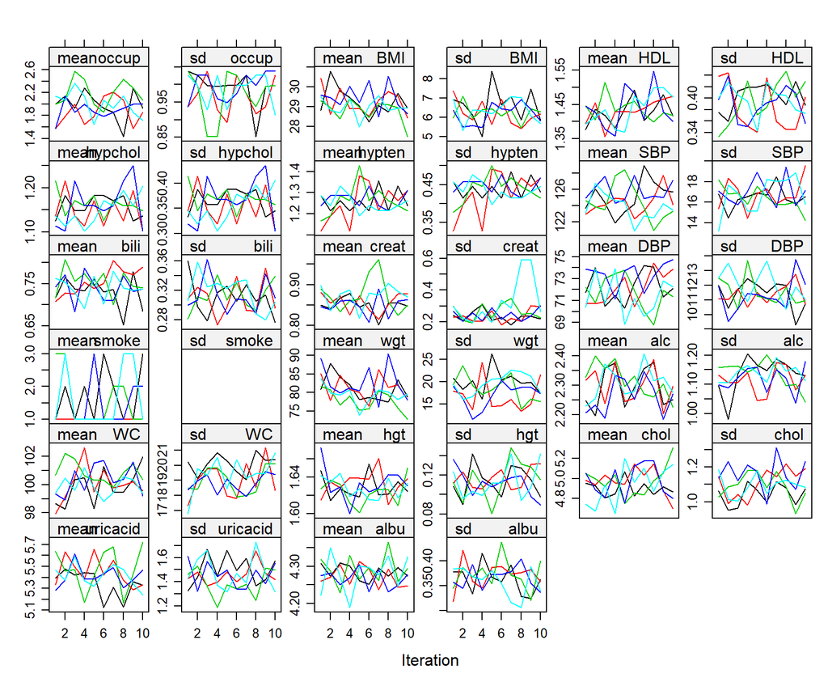

```r
# implemented plotting function (use layout to change the number of rows and columns)
plot(imp, layout = c(6, 6))
```

The chains in `imp` seem to have converged, however it is difficult to judge this based on only 10 iterations. In practice, more iterations should be done.

To save you some time, I ran the imputation again with 30 iterations and the traceplots confirm convergence:

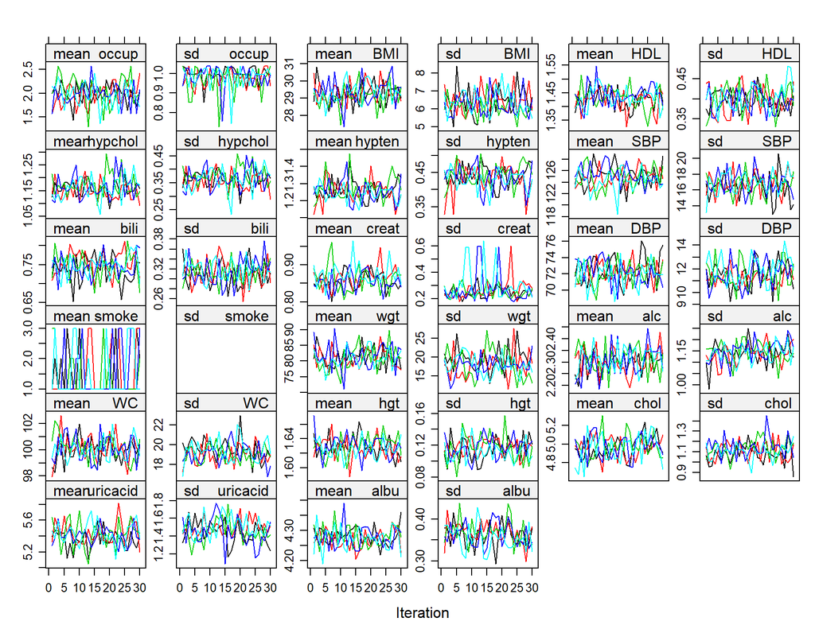

```r
plot(imp30, layout = c(6, 6))
```

#### Continue

In comparison, `impnaive` had some convergence problems:

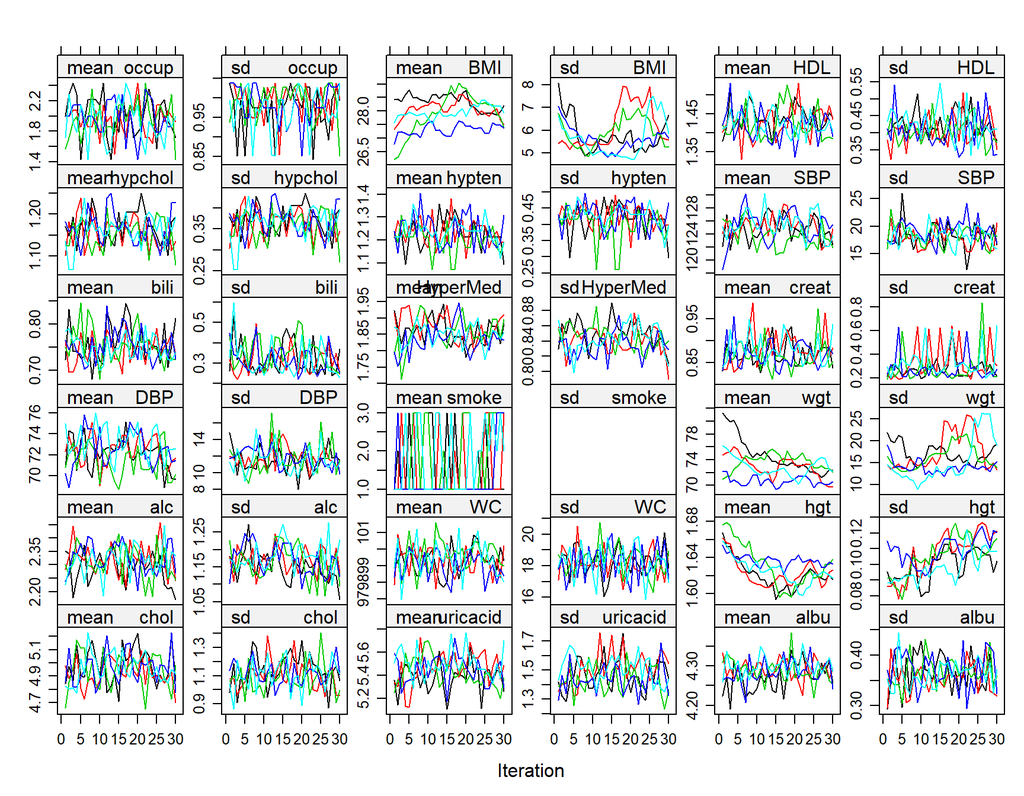

```r
plot(impnaive, layout = c(6, 6))
```

`hgt`, and `wgt` show a clear trend and the chains do not mix well, i.e., there is more variation between the chains than within each chain. (the same is the case for `BMI`).

These are clear signs that there is correlation or identification problems between these variables and some other variables (which is why we made adjustments to the `predictorMatrix` for `imp`).

### Imputed values

Now that we know that `imp` has converged, we can compare the distribution of the imputed values against the distribution of the observed values. When our imputation models fitted the data well, they should have similar distributions (conditional on the covariates used in the imputation model).

#### Task 1

- Plot the distributions of the imputed variables (continuous and categorical).
- Make sure the imputed values are realistic (e.g., height of 2.50m or weight of 10kg for adults).

You can use `densityplot()` and `propplot()` to get plots for all continuous and categorical variables.

To check all imputed values you can either get a summary of the `imp` element of the `mids` object or create a complete dataset containing all imputations using the function `complete()` and get the summary of that.

#### Solution 1

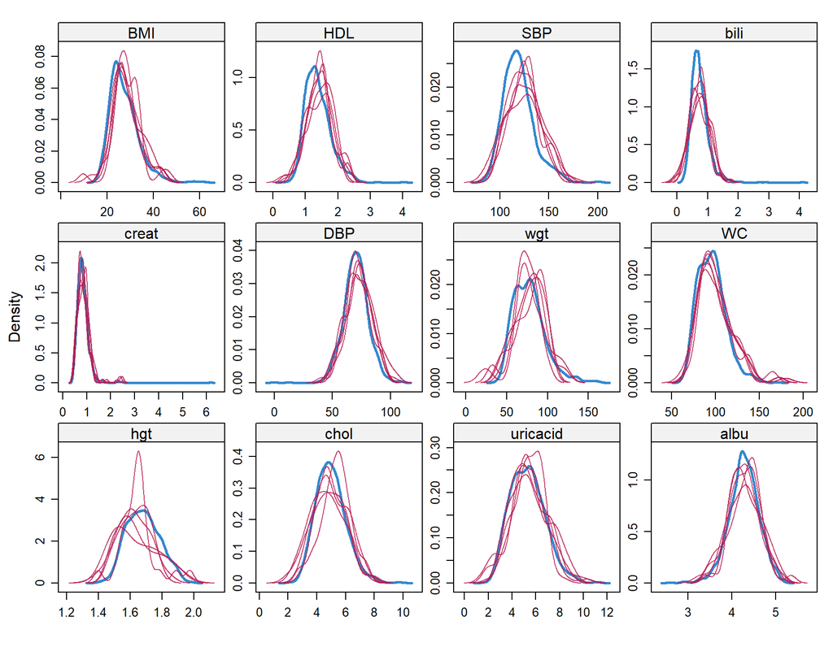

```r
# plot densities of continuous variables
densityplot(imp)
```

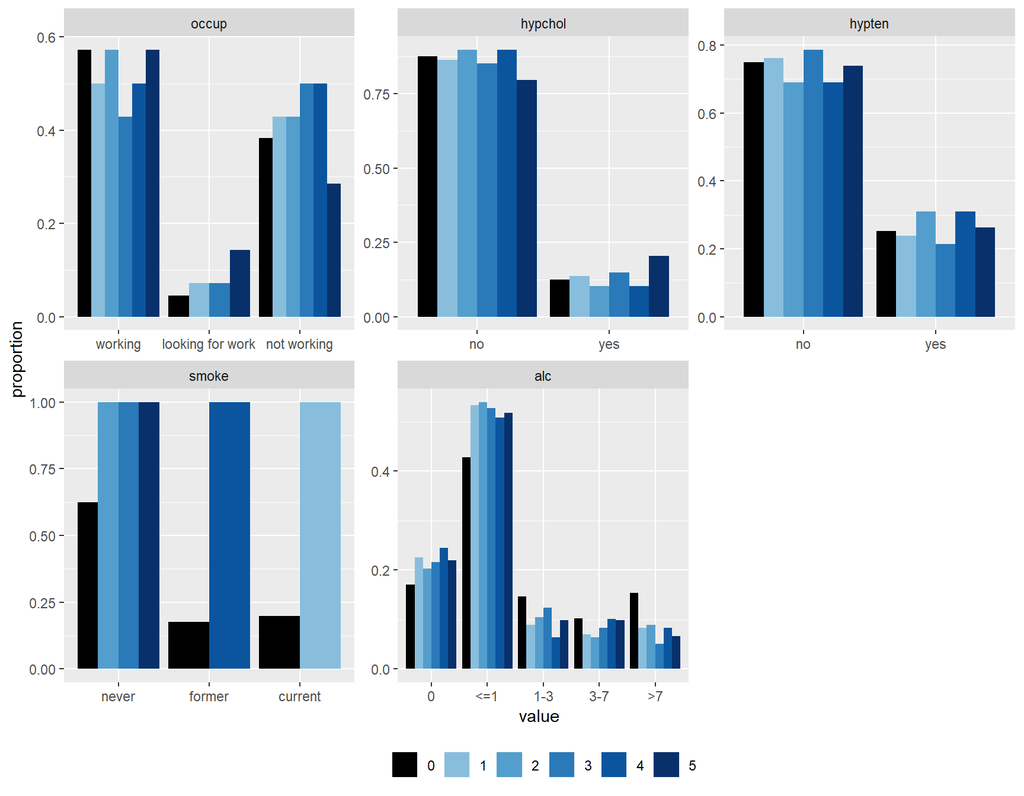

```r
# plot for all categorical variables
propplot(imp)
```

```r
# get the summary of the "the" imputed values
sapply(Filter(function(x) nrow(x) > 0, imp$imp),
       function(x) summary(unlist(x))
)
```

```
## $occup
##          working looking for work      not working
##               36                4               30
##
## $BMI
##    Min. 1st Qu.  Median    Mean 3rd Qu.    Max.
##   9.542  24.610  27.427  28.480  31.860  46.500
##
## $HDL
##    Min. 1st Qu.  Median    Mean 3rd Qu.    Max.
##  0.2675  1.1731  1.4546  1.4361  1.6950  2.4059
##
## $hypchol
##  no yes
## 379  61
##
## $hypten
##  no yes
## 154  56
##
## $SBP
##    Min. 1st Qu.  Median    Mean 3rd Qu.    Max.
##   86.33  113.41  124.78  124.75  135.14  173.70
##
## $bili
##    Min. 1st Qu.  Median    Mean 3rd Qu.    Max.
## -0.1341  0.5115  0.7478  0.7380  0.9366  1.7476
##
## $HyperMed
##    Mode    NA's
## logical    4085
##
## $creat
##    Min. 1st Qu.  Median    Mean 3rd Qu.    Max.
##  0.4500  0.6900  0.8300  0.8613  0.9800  2.5000
##
## $DBP
##    Min. 1st Qu.  Median    Mean 3rd Qu.    Max.
##   40.65   66.32   72.58   72.86   80.76  105.51
##
```

[output cut: 16 more lines]

```
## $hgt
##    Min. 1st Qu.  Median    Mean 3rd Qu.    Max.
##   1.398   1.556   1.624   1.635   1.705   1.974
##
## $chol
##    Min. 1st Qu.  Median    Mean 3rd Qu.    Max.
##   1.834   4.147   4.922   4.962   5.814   7.960
##
## $uricacid
##    Min. 1st Qu.  Median    Mean 3rd Qu.    Max.
##   1.432   4.445   5.292   5.419   6.359  10.297
##
## $albu
##    Min. 1st Qu.  Median    Mean 3rd Qu.    Max.
##   3.194   4.040   4.289   4.284   4.521   5.380
```

Unfortunately, we have some negative imputed values for `bili`. Often, this would not result in bias in the analysis, but may be difficult to explain when providing a summary of the imputed data in a publication. In the present example we can see that the observed values have a slightly right-skewed distribution compared to the imputed values. Re-doing the imputation with `pmm` instead of `norm` for `bili` should fix this. (However, since the imputations seem fine overall, and there is little knowledge gain in re-doing the previous steps, we will skip this repetition in this practical.)

The distributions of the imputed values for `hgt` and `SBP` differ a bit from the distributions of the observed data.

#### Task 2

Investigate if differences in the distributions of observed and imputed values, can be explained by other variables. Check this for

- `SBP` conditional on `gender` and `hypten`
- `hgt` conditional on `gender`
- `alc` conditional on `gender` or `smoke`

#### Solution 2

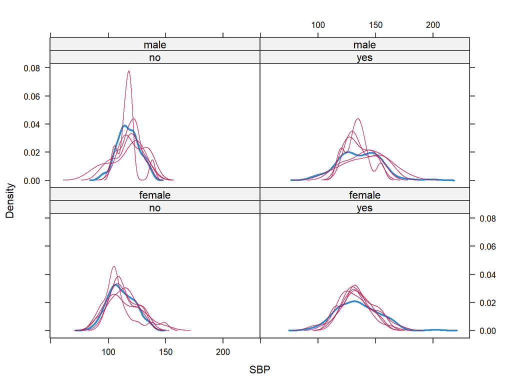

```r
densityplot(imp, ~SBP|hypten + gender)
```

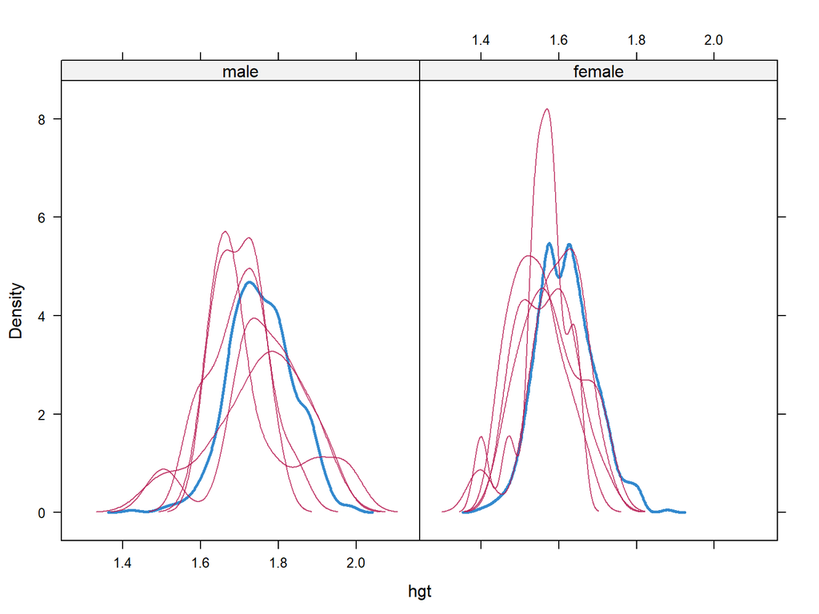

```r
densityplot(imp, ~hgt|gender)
```

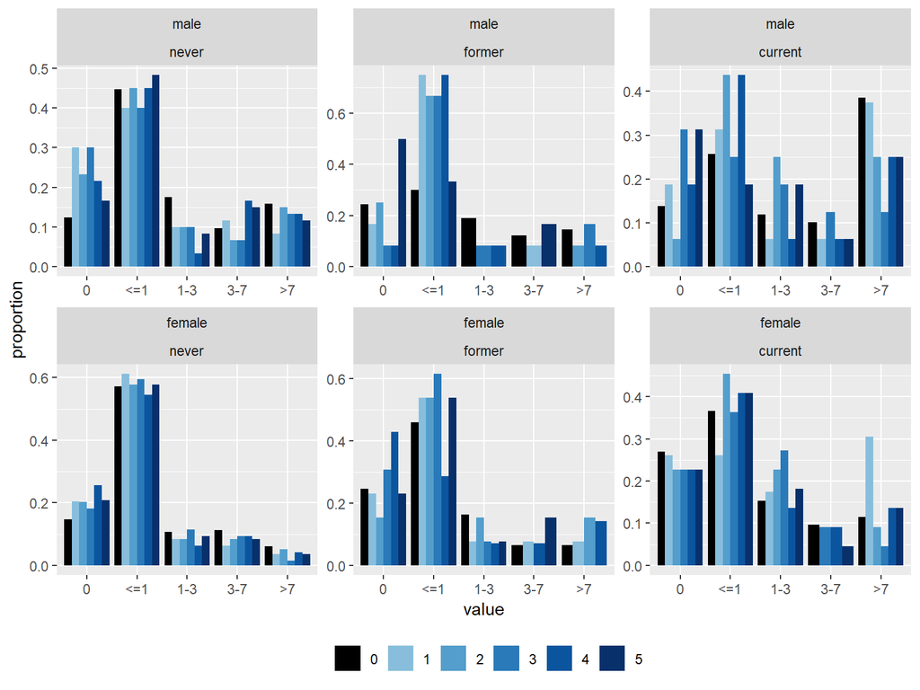

```r
propplot(imp, alc ~ gender + smoke)
```

© Nicole Erler